# DiscussionFads_v3 slides

## A Discussion of *Theory of Fads, Fashion, Custom, and Cultural Change as Informational Cascades*

- Tao Wang, Johns Hopkins University
- April 2, 2019
- Topics in Economic Theory and Finance Seminar by Prof. Brendan Daley

### Highlights of the Paper

- **information cascade**: simply follows previous agent's action regardless of private signals
- not just localized conformity, but also sudden changes and reversal of the fashion
- an informational mechanism beyond traditional mechanisms
  - punishment of deviations
  - positive externality
  - conformity preference
  - communication

### A Toy Model

- n agents;
- each one makes discrete choice of adoption or rejection;
- fixed cost of adoption $C$, set to be $1/2$;
- value of adoption being 1 and 0 with equal probability 1/2;
- general decision rule: adopt if $\pi\times V+(1-\pi)\times 0 > 1/2$, where $\pi$ is the posterior for $V=1$, thus the pivotal posterior is $1/2$;
- imperfect singal for agent $i$ is $p$ generated based on following table, for instance $Prob(H|V=1)=p$, assume $p>1/2$, the signal is useful.

|  | High Signal | Low Signal |
| --- | --- | --- |
| $V$=1 | $p$ | $1-p$ |
| $V$=0 | $1-p$ | $p$ |

- individual signal conditionally independent;
- individual $i$ can only observe previous actions;

#### Deision sequence

Each agent's action is a function of previous action and her own signal $a_i(A_{i-1},s_i)$

- 1st adopts if H, rejects if L;
- 2nd:
  - if 1st adopts, 2nd adopts if H, indifferent if L;
  - if 1st rejects, 2nd rejects if L, indifferent if H;
- 3nd
  - if first two adopt, adopts **regardless of signal**
  - if first two reject, rejects **regardless of signal**
  - if one reject and one adopt, indifferent if one rejects and one adopts before him
- ...

```python
### Simulation
n_sim = 10      # nb of simulations
p= 1/2+0.000000001   # prob(H|V=1)
nb = 20   # nb of decision maker
#pb_cascade=[]
#pb_c_cascade=[]
#pb_w_cascade=[]
for i in range(n_sim):
    nb_adopt = 0
    adopt=[]
    sig=np.random.choice(2,nb,p)
    for ii in range(nb):
        adopt.append(adopt_rule(nb_adopt,ii,sig[ii],p))
        nb_adopt=nb_adopt+adopt_rule(nb_adopt,ii,sig[ii],p)
    print('Total number of adoption is '+str(nb_adopt))
    print('The sequence of decision is '+str(adopt))
```

```
Total number of adoption is 20
The sequence of decision is [1, 1, 1, 1, 1, 1, 1, 1, 1, 1, 1, 1, 1, 1, 1, 1, 1, 1, 1, 1]
Total number of adoption is 2.0
The sequence of decision is [0, 0.5, 0.5, 0.5, 0.5, 0, 0, 0, 0, 0, 0, 0, 0, 0, 0, 0, 0, 0, 0, 0]
Total number of adoption is 0
The sequence of decision is [0, 0, 0, 0, 0, 0, 0, 0, 0, 0, 0, 0, 0, 0, 0, 0, 0, 0, 0, 0]
Total number of adoption is 17.0
The sequence of decision is [1, 0.5, 0.5, 0.5, 0.5, 0.5, 0.5, 1, 1, 1, 1, 1, 1, 1, 1, 1, 1, 1, 1, 1]
Total number of adoption is 20
The sequence of decision is [1, 1, 1, 1, 1, 1, 1, 1, 1, 1, 1, 1, 1, 1, 1, 1, 1, 1, 1, 1]
Total number of adoption is 19.5
The sequence of decision is [1, 0.5, 1, 1, 1, 1, 1, 1, 1, 1, 1, 1, 1, 1, 1, 1, 1, 1, 1, 1]
Total number of adoption is 19.5
The sequence of decision is [1, 0.5, 1, 1, 1, 1, 1, 1, 1, 1, 1, 1, 1, 1, 1, 1, 1, 1, 1, 1]
Total number of adoption is 20
The sequence of decision is [1, 1, 1, 1, 1, 1, 1, 1, 1, 1, 1, 1, 1, 1, 1, 1, 1, 1, 1, 1]
Total number of adoption is 19.5
The sequence of decision is [1, 0.5, 1, 1, 1, 1, 1, 1, 1, 1, 1, 1, 1, 1, 1, 1, 1, 1, 1, 1]
Total number of adoption is 20
The sequence of decision is [1, 1, 1, 1, 1, 1, 1, 1, 1, 1, 1, 1, 1, 1, 1, 1, 1, 1, 1, 1]
```

#### till the 3rd, conditional probability of information cascade

- Given V=1

\begin{eqnarray} \text{prob}(\text{correct cascade}) = \underbrace{p*p}_{\text{prob}(HH)} + \underbrace{p(1-p)*1/2}_{\text{prob}(\text{HL but the 2st adopts})} \end{eqnarray}\begin{eqnarray} \text{prob}(\text{wrong cascade}) = \underbrace{(1-p)*(1-p)}_{\text{prob}(LL)} + \underbrace{(1-p)*p*1/2}_{\text{prob}(\text{LH but the 2st rejects})} \end{eqnarray}

| correct cascade | no cascade | wrong cascade |
| --- | --- | --- |
| $\frac{p(1+p)}{2}$ | $p-p^2$ | $\frac{(p-2)(p-1)}{2}$ |

...

#### till the (n+1)th, ex ante probability of information cascade

- cascade only happens after even numbers of people:
  - think about after 3 individuals: either it has happend after 2, or the third one is still using her own signal.
- in correct cascade after n people:

\begin{eqnarray} \begin{split} \underbrace{\text{prob}(\text{in correct cascade after n people})}_{\textbf{P}^n} = & \underbrace{\text{prob}(\text{in correct cascade after n-2 people})}_{\textbf{P}^{n-2}} \\ & + \underbrace{\text{prob}(\text{not in correct cascade after n-2 people})}_{1-\textbf{P}^{n-2}}* \underbrace{\frac{p(1+p)}{2}}_{\textbf{P}^2} \end{split} \end{eqnarray}

| correct cascade | no cascade | wrong cascade |
| --- | --- | --- |
| $\frac{p(p+1)[1-(p-p^2)^{n/2}]}{2(1-p+p^2)}$ | $(p-p^2)^{n/2}$ | $\frac{(p-2)(p-1)[1-(p-p^2)^{n/2}]}{2(1-p+p^2)}$ |

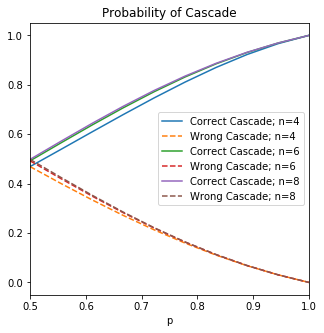

```python
# Plot
plt.figure(figsize=[5,5])

p = np.linspace(0.5001,0.9999,10)
n_list = np.array([4,6,8])

for n in n_list:
    prob_co = p*(p+1)*(1-(p-p**2)**(n/2))/2/(1-p+p**2)
    prob_wr = (p-2)*(p-1)*(1-(p-p**2)**(n/2))/2/(1-p+p**2)
    plt.plot(p,prob_co,label="Correct Cascade; n="+str(n))
    plt.plot(p,prob_wr,'--',label="Wrong Cascade; n="+str(n))
    plt.legend(loc=0)
    plt.xlabel('p')
    plt.xlim([0.5,1])
    plt.title("Probability of Cascade")
plt.show()
```

### Questions

- how often information cascade occurs?
- what are those conditions?
- is it fragile?
- what factors reverse the cascade

### Generalized Model

- n agents;
- a finite number of values: $v_1$, $v_2$.. $v_l$...$v_s$
- no trivial decision $v_1< C < v_s$
- a finite number of signals: $x_1$, $x_2$... $x_q$...$x_R$
- prior of value bing $v_l$ is $\mu_l$;
- conditional probability: $p_{ql}=prob(x_q|v_l)$
- Perfect Bayesian Equilibrium: sequentially rational and consistent.

#### Two conditions for which information cascade eventually arise as n goes to $\infty$

- **Condition 1** MLRO properties of signal and values.

\begin{eqnarray} \frac{p_{q+1,l+1}}{p_{q,l+1}} \geq \frac{p_{q+1,l}}{p_{q,l}} \quad \forall q < R \end{eqnarray}

- **Condition 2** No long-run ties. $\forall q$ $v_q \neq C$. As agent gets closer to true value, she is still not indifferent to adopting and rejecting.

#### Result 1.

If condition 1 and 2 hold, as $n \rightarrow \infty$, $\text{prob(information cascade occurs)} \rightarrow 1$

```
 An information cascade eventually begins.
```

#### Result 2. Different precisions of signal(different p's in binary case)

- **Lower precision** of leader makes later followers better off. It makes later followers use their own information.

### Fragility of Cascades

#### Result 3. public release of information

- Release of **noisy enough** public information before the first individual's decision can make some individuals worse off.

#### the depth of cascade

- Result 4. If all individuals' signals are drawn from the same distribution, then after the cascade has begun, all individuals welcome public information.
- Result 5. The realse of a **noisier public signal** than private information can shatter a long-lasting cascade.

  ```
  Millions of smoke need not discourage investigation of side effects of smoking.
  ```

- Result 6. If there is a non-zero probability of release of public information before everyone makes the decision, then eventually the population settles into the correct cascade.

#### reversal of cascades

- Probability of cascade reversal is higher than the probability of correct choice. Higher than the full information regime.

### Examples

#### model assumptions

1. sequential actions
2. observe private signals plus previous actions
3. observable actions, not verbal communications
4. no other mechanisms enforcing conformity

#### model implications

1. local or idiosyncratic
2. fragility
3. some agents ignore private information

#### phenomenon

- Zoology
- Medical practice and scientific theory
- Finance
- Peer influence and stigma